# Lab 2: Data Understanding & Exploratory Data Analysis

- Show All Code
- Hide All Code
- View Source

CRISP-DM Phase 2 — Carseats Case

Author

Prof. Dr. Jörg Schoder

Published

March 20, 2026

## 1 Learning Objectives and Overview

**NoteLearning Objectives**

- Establish EDA as a mandatory first *step to understand the data* before modelling (e.g. regression analysis)
- Explore the Carseats dataset: structure, variable types, distributions
- Understand what EDA is (**descriptive** and **inductive**)…
- …and, equally importantly, what it is *not* (confirmatory, predictive, inferential)
- Recognise why EDA-derived hypotheses cannot be tested on the same data — and know what to do instead
- Visualise bivariate relationships and formulate hypotheses for modelling

**Scenario:** You are the data scientist of a retail chain with 400 stores. The business goal (CRISP-DM Phase 1) is already defined: identify underperforming stores so that management can take targeted action. Before any model is built, the data must be understood. That is CRISP-DM Phase 2: **Data Understanding** — the focus of this lab.

## 2 🧭 How to Navigate This Lab

| Symbol | Box colour | Meaning | When to read |
| --- | --- | --- | --- |
| ⚠️ | **Red** — Action Required | Run code, interpret output, answer questions | **Do this in the live session** |
| 💡 | **Green** — Best Practice / Tip | Coding tips, R functions, shortcuts | Skim in the lab |
| 📚 | **Blue, collapsed** — Background Theory | Concepts, theory, context | Skip in the lab — read at home |
| ℹ️ | **Blue, open** — Note | Short clarifications and reminders | Read when you reach them |

Normal text and code chunks are the main content — work through them in order. Background sections are marked with a collapsed blue box and can be expanded at any time.

⏱ **20 minutes** for mandatory tasks (A1–A5). Bonus tasks if time permits.

## 3 Icebreaker: Never Trust a Statistic You Haven’t Plotted

Before we turn to the Carseats data, a quick thought experiment. The table below shows descriptive statistics for 13 different datasets: means, standard deviations, and the correlation between x and y.

```r
library(datasauRus)

datasaurus_dozen |>
  group_by(dataset) |>
  summarise(
    n      = n(),
    mean_x = mean(x),
    mean_y = mean(y),
    sd_x   = sd(x),
    sd_y   = sd(y),
    cor_xy = cor(x, y)
  ) |>
  gt() |>
  fmt_number(columns = where(is.numeric), decimals = 2) |>
  tab_header(
    title    = "Summary Statistics: Datasaurus Dozen",
    subtitle = "Means, standard deviations, and correlations look virtually identical across all 13 datasets."
  ) |>
  tab_style(
    style     = cell_fill(color = "#fff8e1"),
    locations = cells_body(rows = dataset == "dino")
  ) |>
  tab_options(table.font.size = "13px")
```

Summary Statistics: Datasaurus Dozen

Means, standard deviations, and correlations look virtually identical across all 13 datasets.

| dataset | n | mean_x | mean_y | sd_x | sd_y | cor_xy |
| --- | --- | --- | --- | --- | --- | --- |
| away | 142.00 | 54.27 | 47.83 | 16.77 | 26.94 | −0.06 |
| bullseye | 142.00 | 54.27 | 47.83 | 16.77 | 26.94 | −0.07 |
| circle | 142.00 | 54.27 | 47.84 | 16.76 | 26.93 | −0.07 |
| dino | 142.00 | 54.26 | 47.83 | 16.77 | 26.94 | −0.06 |
| dots | 142.00 | 54.26 | 47.84 | 16.77 | 26.93 | −0.06 |
| h_lines | 142.00 | 54.26 | 47.83 | 16.77 | 26.94 | −0.06 |
| high_lines | 142.00 | 54.27 | 47.84 | 16.77 | 26.94 | −0.07 |
| slant_down | 142.00 | 54.27 | 47.84 | 16.77 | 26.94 | −0.07 |
| slant_up | 142.00 | 54.27 | 47.83 | 16.77 | 26.94 | −0.07 |
| star | 142.00 | 54.27 | 47.84 | 16.77 | 26.93 | −0.06 |
| v_lines | 142.00 | 54.27 | 47.84 | 16.77 | 26.94 | −0.07 |
| wide_lines | 142.00 | 54.27 | 47.83 | 16.77 | 26.94 | −0.07 |
| x_shape | 142.00 | 54.26 | 47.84 | 16.77 | 26.93 | −0.07 |

Statistically, these 13 datasets are almost indistinguishable. An algorithm working from summary statistics alone would treat them identically. Now look at the actual data:

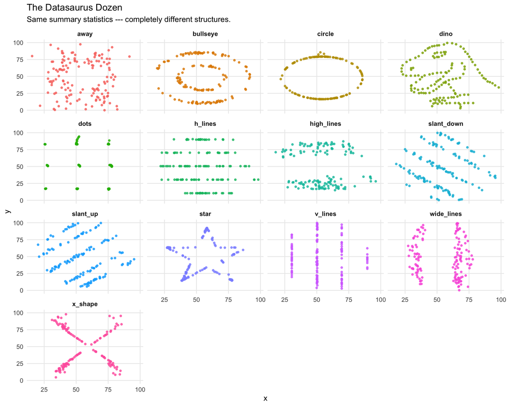

```r
datasaurus_dozen |>
  ggplot(aes(x = x, y = y, color = dataset)) +
  geom_point(alpha = 0.8, size = 1.0) +
  theme_minimal(base_size = 11) +
  theme(
    legend.position  = "none",
    strip.text       = element_text(face = "bold", size = 9),
    panel.grid.minor = element_blank()
  ) +
  facet_wrap(~dataset, ncol = 4) +
  labs(
    title    = "The Datasaurus Dozen",
    subtitle = "Same summary statistics --- completely different structures.",
    x = "x", y = "y"
  )
```

**ImportantThe Central Lesson**

The numbers in the table are almost identical. The plots reveal a dinosaur, a star, a circle, an X, and several other completely different shapes — all with the same mean, standard deviation, and correlation.

**Conclusion: summary statistics are a necessary but not sufficient description of data. Visualisation is not optional — it is the primary EDA tool.**

This motivates everything we do in this lab.

## 4 Background: Where We Are in CRISP-DM

In the lecture, **Phase 1 (Business Understanding)** was introduced: the business goal is to identify underperforming stores. The question is now: do our data support this goal? What do they contain? What is their quality? These are Phase 2 questions.

| Phase | Name | Content | Status |
| --- | --- | --- | --- |
| 1 | Business Understanding | Goal: identify underperforming stores | Done (lecture) |
| 2 | Data Understanding | EDA: structure, quality, distributions, patterns | ← This lab |
| 3 | Data Preparation | Cleaning, encoding, feature engineering | Lab 3 |
| 4 | Modelling | Regression model: Sales ~ Price + ... | Lab 3 + Demo |
| 5 | Evaluation | R², residuals, OVB check | Demo + Lab 4 |
| 6 | Deployment | Performance ranking, managerial memo | Lab 4 |

**Note📚 Background: EDA and Data Mining — Orientation**

EDA and Data Mining (DM) are frequently used interchangeably in practice — and there are genuine overlaps. Both are **data-driven and inductive**: they do not wait for a pre-specified hypothesis but search for structure in the data. This distinguishes both from classical confirmatory statistics, which starts from a hypothesis and asks whether the data are consistent with it.

The differences lie in *purpose*, *scale*, and *success criteria*:

**What they share:** Both use statistical summaries and algorithms to separate signal from noise. Both are iterative. Both treat the data as the source of new questions.

**Where they diverge:**

| Aspect | EDA | Data Mining (DM) |
| --- | --- | --- |
| **Central actor** | The human analyst: visualisation serves cognitive understanding | The algorithm: detects patterns at scales humans cannot see |
| **Dimensionality** | Low: 2D/3D visualisations and descriptive statistics | High: hundreds of variables simultaneously (“Big Data”) |
| **Goal** | Understanding, intuition, error detection, hypothesis generation | Extraction of stable, commercially exploitable patterns |
| **Type of insight** | Phenomenological — “What do these data show?” | Pragmatic — “Which patterns are stable enough for profit or prediction?” |
| **Methods** | Plotting, transformation, outlier inspection, correlation | Association rules, clustering, classification, regression models |
| **Human involvement** | Interactive and manual: analyst is in the feedback loop | Automated and scalable |
| **Validation** | Plausibility and visual confirmation | Performance metrics: lift, accuracy, ROI |
| **Causality** | Seeks logical-conceptual connections; generates hypotheses | Stable correlations are sufficient (“black box” acceptable if profitable) |
| **Success** | New question generated; anomaly noticed; pattern understood | Prediction accurate; model deployable; ROI positive |

**NoteThe Grey Zone**

The boundary is genuinely blurry. When we fit a regression line to a scatter plot, are we doing EDA or Data Mining?

- **In EDA:** the line is a *visual summary* — a conditional mean drawn to make a trend perceptible. We look at it, think about it, and decide what to ask next.
- **In DM:** the same line is a *deployed model*, evaluated on held-out data by RMSE and compared against alternatives.

Same technique, different epistemic frame. In this lab, all models are EDA tools — they serve understanding, not deployment. The shift to DM begins in Lab 3.

### 4.1 The Induction Trap

Both EDA and DM are inductive. This creates a constraint that is easy to overlook.

**WarningHypotheses from EDA Cannot Be Tested on the Same Data**

**The rule:** A hypothesis generated by looking at a dataset cannot be validly tested on that same dataset.

Any pattern you discover inductively will appear confirmed by a statistical test on the same observations — by construction. The result will look significant, but you have learned nothing new: you are simply re-describing what you already saw. This is called **circular inference** (or: data dredging).

> *In our case:* After this lab you will have noticed that `ShelveLoc` seems associated with `Sales`. Running a statistical test on the same 400 stores to “confirm” this would be circular. The data have already been interrogated; they cannot serve as their own judge.

**What to do instead:** Split the data *before* any exploration — one part for EDA, one part for later testing. This protects the confirmation step from being contaminated by the exploration step.

- The statistical tools for the confirmation step (p-values, confidence intervals) are the topic of **Session 2**.
- A practical framework for designing valid tests from the outset — **A/B testing** — is introduced in **Session 3**.

**For now: EDA generates questions. It does not answer them.**

## 5 Step 1: Getting to Know the Dataset

### 5.1 Structural Overview

```r
glimpse(tbl_carseats)
```

```
Rows: 400
Columns: 11
$ Sales       <dbl> 9.50, 11.22, 10.06, 7.40, 4.15, 10.81, 6.63, 11.85, 6.54, …
$ CompPrice   <dbl> 138, 111, 113, 117, 141, 124, 115, 136, 132, 132, 121, 117…
$ Income      <dbl> 73, 48, 35, 100, 64, 113, 105, 81, 110, 113, 78, 94, 35, 2…
$ Advertising <dbl> 11, 16, 10, 4, 3, 13, 0, 15, 0, 0, 9, 4, 2, 11, 11, 5, 0, …
$ Population  <dbl> 276, 260, 269, 466, 340, 501, 45, 425, 108, 131, 150, 503,…
$ Price       <dbl> 120, 83, 80, 97, 128, 72, 108, 120, 124, 124, 100, 94, 136…
$ ShelveLoc   <fct> Bad, Good, Medium, Medium, Bad, Bad, Medium, Good, Medium,…
$ Age         <dbl> 42, 65, 59, 55, 38, 78, 71, 67, 76, 76, 26, 50, 62, 53, 52…
$ Education   <dbl> 17, 10, 12, 14, 13, 16, 15, 10, 10, 17, 10, 13, 18, 18, 18…
$ Urban       <fct> Yes, Yes, Yes, Yes, Yes, No, Yes, Yes, No, No, No, Yes, Ye…
$ US          <fct> Yes, Yes, Yes, Yes, No, Yes, No, Yes, No, Yes, Yes, Yes, N…
```

**Tip💡 What to read from `glimpse()`**

- Number of rows (stores) and columns (variables)
- Data types: `<dbl>` = numeric, `<chr>` = character/text
- First values: do they look plausible?

### 5.2 Comprehensive Summary with `skim()`

`skim()` from the `skimr` package gives a structured, type-aware overview in one call: missing values, quantiles, mean, standard deviation, and a small inline histogram.

```r
tbl_carseats |> skim()
```

Data summary

| Name | tbl_carseats |
| --- | --- |
| Number of rows | 400 |
| Number of columns | 11 |
| _______________________ |  |
| Column type frequency: |  |
| factor | 3 |
| numeric | 8 |
| ________________________ |  |
| Group variables | None |

**Variable type: factor**

| skim_variable | n_missing | complete_rate | ordered | n_unique | top_counts |
| --- | --- | --- | --- | --- | --- |
| ShelveLoc | 0 | 1 | FALSE | 3 | Med: 219, Bad: 96, Goo: 85 |
| Urban | 0 | 1 | FALSE | 2 | Yes: 282, No: 118 |
| US | 0 | 1 | FALSE | 2 | Yes: 258, No: 142 |

**Variable type: numeric**

| skim_variable | n_missing | complete_rate | mean | sd | p0 | p25 | p50 | p75 | p100 | hist |
| --- | --- | --- | --- | --- | --- | --- | --- | --- | --- | --- |
| Sales | 0 | 1 | 7.50 | 2.82 | 0 | 5.39 | 7.49 | 9.32 | 16.27 | ▁▆▇▃▁ |
| CompPrice | 0 | 1 | 124.97 | 15.33 | 77 | 115.00 | 125.00 | 135.00 | 175.00 | ▁▅▇▃▁ |
| Income | 0 | 1 | 68.66 | 27.99 | 21 | 42.75 | 69.00 | 91.00 | 120.00 | ▇▆▇▆▅ |
| Advertising | 0 | 1 | 6.64 | 6.65 | 0 | 0.00 | 5.00 | 12.00 | 29.00 | ▇▃▃▁▁ |
| Population | 0 | 1 | 264.84 | 147.38 | 10 | 139.00 | 272.00 | 398.50 | 509.00 | ▇▇▇▇▇ |
| Price | 0 | 1 | 115.79 | 23.68 | 24 | 100.00 | 117.00 | 131.00 | 191.00 | ▁▂▇▆▁ |
| Age | 0 | 1 | 53.32 | 16.20 | 25 | 39.75 | 54.50 | 66.00 | 80.00 | ▇▆▇▇▇ |
| Education | 0 | 1 | 13.90 | 2.62 | 10 | 12.00 | 14.00 | 16.00 | 18.00 | ▇▇▃▇▇ |

**Note📚 Background: Reading a `skim()` output**

The output is split by data type. For numeric variables, pay attention to:

- `n_missing`: missing values — here 0 for all variables, so no imputation needed.
- `mean` and `p50` (median): if they diverge noticeably, the distribution is skewed.
- `hist`: the inline sparkline gives a first impression of shape.
- `sd`, `p0`, `p100`: range and spread — are there implausible extremes?

### 5.3 Frequency Tables for Categorical Variables

For categorical variables, `count()` and `tabyl()` (from `janitor`) give counts and proportions in one step.

```r
library(janitor)

# Simple count
tbl_carseats |> count(ShelveLoc, sort = TRUE)
```

```
# A tibble: 3 × 2
  ShelveLoc     n
  <fct>     <int>
1 Medium      219
2 Bad          96
3 Good         85
```

```r
# With proportions
tbl_carseats |>
  tabyl(ShelveLoc) |>
  adorn_pct_formatting(digits = 1) |>
  gt() |>
  tab_options(table.font.size = "13px")
```

| ShelveLoc | n | percent |
| --- | --- | --- |
| Bad | 96 | 24.0% |
| Good | 85 | 21.2% |
| Medium | 219 | 54.8% |

```r
# Cross-tabulation: Urban × US
tbl_carseats |>
  tabyl(Urban, US) |>
  adorn_totals(c("row", "col")) |>
  adorn_percentages("all") |>
  adorn_pct_formatting(digits = 1) |>
  adorn_ns() |>
  gt() |>
  tab_header(title = "Urban × US: counts (%) of all 400 stores") |>
  tab_options(table.font.size = "13px")
```

Urban × US: counts (%) of all 400 stores

| Urban | No | Yes | Total |
| --- | --- | --- | --- |
| No | 11.5% (46) | 18.0% (72) | 29.5% (118) |
| Yes | 24.0% (96) | 46.5% (186) | 70.5% (282) |
| Total | 35.5% (142) | 64.5% (258) | 100.0% (400) |

### 5.4 Extended Descriptives with `psych::describe()`

`describe()` from the `psych` package adds skewness and kurtosis to the standard summary — useful for assessing distributional shape.

```r
library(psych)

tbl_carseats |>
  select(Sales, Price, Advertising, Income, Age, Population) |>
  describe() |>
  as_tibble(rownames = "variable") |>
  select(variable, n, mean, sd, median, min, max, skew, kurtosis) |>
  gt() |>
  fmt_number(columns = where(is.numeric), decimals = 2) |>
  tab_style(
    style     = cell_fill(color = "#fff8e1"),
    locations = cells_body(rows = variable == "Sales")
  ) |>
  tab_options(table.font.size = "13px") |>
  tab_footnote("Skew: |value| < 0.5 = approximately symmetric; > 1 = notably skewed")
```

| variable | n | mean | sd | median | min | max | skew | kurtosis |
| --- | --- | --- | --- | --- | --- | --- | --- | --- |
| Sales | 400.00 | 7.50 | 2.82 | 7.49 | 0.00 | 16.27 | 0.18 | −0.11 |
| Price | 400.00 | 115.79 | 23.68 | 117.00 | 24.00 | 191.00 | −0.12 | 0.41 |
| Advertising | 400.00 | 6.64 | 6.65 | 5.00 | 0.00 | 29.00 | 0.63 | −0.57 |
| Income | 400.00 | 68.66 | 27.99 | 69.00 | 21.00 | 120.00 | 0.05 | −1.10 |
| Age | 400.00 | 53.32 | 16.20 | 54.50 | 25.00 | 80.00 | −0.08 | −1.14 |
| Population | 400.00 | 264.84 | 147.38 | 272.00 | 10.00 | 509.00 | −0.05 | −1.21 |

Skew: |value| < 0.5 = approximately symmetric; > 1 = notably skewed

### 5.5 Quick Data Quality Overview with `DataExplorer`

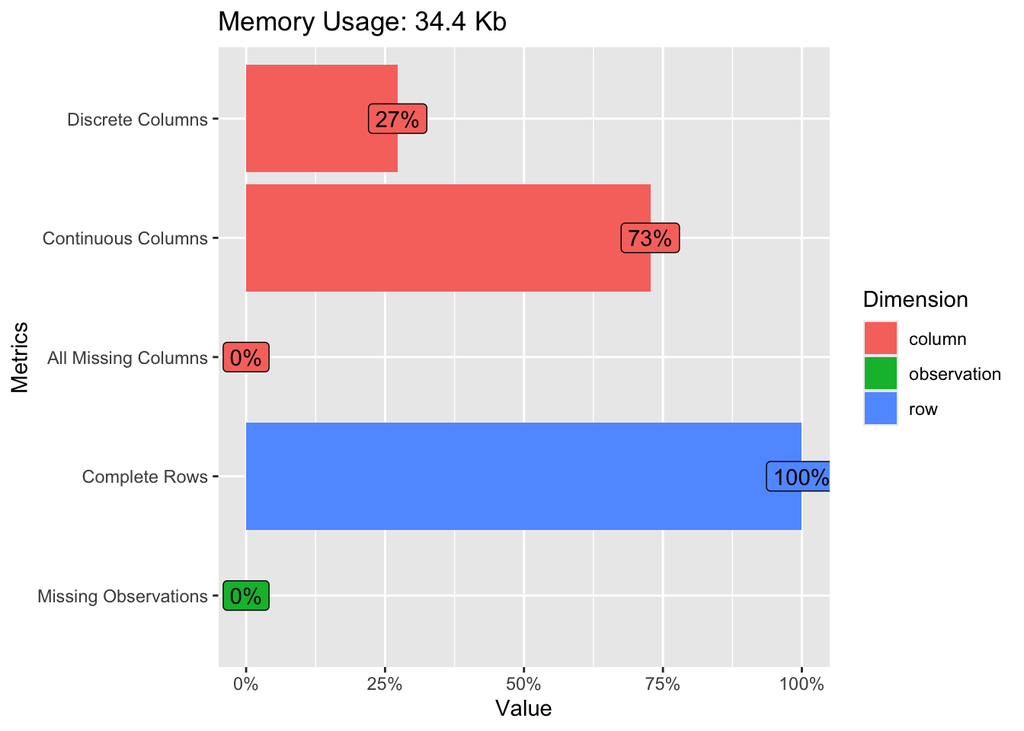

```r
library(DataExplorer)

# Types and missings at a glance
plot_intro(tbl_carseats)
```

`plot_intro()` summarises the entire dataset in a single figure: how many variables are continuous vs. discrete, whether any columns or rows are entirely empty, the overall share of missing values, and the proportion of complete rows. For the Carseats data the result is a clean bill of health — no missings, types as expected. In practice this is the first thing to check after import, before any further analysis.

**Important⚠️ A1: Explore the Dataset**

Using `glimpse()`, `skim()`, `tabyl()`, and `describe()`:

1. How many stores and variables does the dataset contain?
2. What is the **range** of `Sales`? What does one unit represent?
3. What proportion of stores have “Good” shelf placement?
4. Which numeric variable has the highest skewness? Does this surprise you?
5. Are there any missing values?

## 6 Step 2: Univariate Distributions

### 6.1 Target Variable: Sales

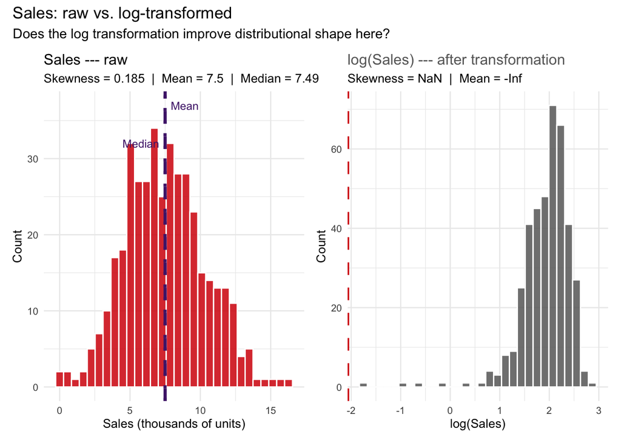

```r
skew_sales <- round(skewness(tbl_carseats$Sales), 3)
skew_log   <- round(skewness(log(tbl_carseats$Sales)), 3)

p_raw <- tbl_carseats |>
  ggplot(aes(x = Sales)) +
  geom_histogram(bins = 30, fill = "#D50006", color = "white", alpha = 0.85) +
  geom_vline(xintercept = mean(tbl_carseats$Sales),
             color = "#502479", linewidth = 1.2, linetype = "dashed") +
  geom_vline(xintercept = median(tbl_carseats$Sales),
             color = "#502479", linewidth = 1.2, linetype = "dotted") +
  annotate("text", x = mean(tbl_carseats$Sales) + 0.4, y = 37,
           label = "Mean", color = "#502479", size = 3.2, hjust = 0) +
  annotate("text", x = median(tbl_carseats$Sales) - 0.4, y = 32,
           label = "Median", color = "#502479", size = 3.2, hjust = 1) +
  labs(
    title    = "Sales --- raw",
    subtitle = paste0("Skewness = ", skew_sales,
                      "  |  Mean = ", round(mean(tbl_carseats$Sales), 2),
                      "  |  Median = ", round(median(tbl_carseats$Sales), 2)),
    x = "Sales (thousands of units)", y = "Count"
  ) +
  theme_minimal(base_size = 10)

p_log <- tbl_carseats |>
  ggplot(aes(x = log(Sales))) +
  geom_histogram(bins = 30, fill = "#686868", color = "white", alpha = 0.85) +
  geom_vline(xintercept = mean(log(tbl_carseats$Sales)),
             color = "#D50006", linewidth = 1.2, linetype = "dashed") +
  labs(
    title    = "log(Sales) --- after transformation",
    subtitle = paste0("Skewness = ", skew_log,
                      "  |  Mean = ", round(mean(log(tbl_carseats$Sales)), 3)),
    x = "log(Sales)", y = "Count"
  ) +
  theme_minimal(base_size = 10) +
  theme(plot.title = element_text(color = "#686868"))

p_raw + p_log +
  plot_annotation(
    title    = "Sales: raw vs. log-transformed",
    subtitle = "Does the log transformation improve distributional shape here?"
  )
```

**Note📚 Background: The Log Transformation — When Does It Help?**

Many econometrics textbooks (Wooldridge, Stock & Watson) present log transformation as a standard remedy for two problems:

- **Right-skewness:** Income, house prices, and firm sizes are almost always right-skewed (a few very large values, many small ones). Logging compresses the upper tail.
- **Interpretability:** Log-transformed models yield coefficients interpretable as elasticities (percentage changes).

Because students typically learn with wage or house price data, a heuristic forms: *“business variable → log-transform.”* But this heuristic conflates two conceptually different types of business variables.

**NoteUnit Sales vs. Revenue — A Critical Distinction**

| Variable type | Typical distribution | Log appropriate? |
| --- | --- | --- |
| **Revenue, wealth, asset prices** | Right-skewed (power-law process: a few very large values) | Usually yes |
| **Unit sales at store level** | Often approximately symmetric | Check empirically — often no |

Why the difference? When we observe *unit sales of a stable consumer good across 400 similar stores*, we are essentially looking at the sum of many independent purchase decisions. The **Central Limit Theorem** applies: the sum (or average) of many independent random variables converges to a normal distribution, regardless of the distribution of individual purchases. The result is symmetry — not skewness.

Revenue, by contrast, is often driven by a small number of very large transactions (power-law dynamics). Log transformation is genuinely appropriate there.

**The Carseats data are a textbook example of this distinction.** `Sales` measures unit sales across 400 stores. The EDA should reveal approximately symmetric data — and indeed it does.

**ImportantEmpirical Verdict for the Carseats Data**

The log transformation makes the distribution *worse*, not better. This is not surprising given the Central Limit Theorem argument above — but it would not have been obvious without looking at the data.

**This is why EDA comes first.** We do not transform because a textbook says to; we transform if and only if the data indicate a need.

### 6.2 All Numeric Variables: Distributions at a Glance

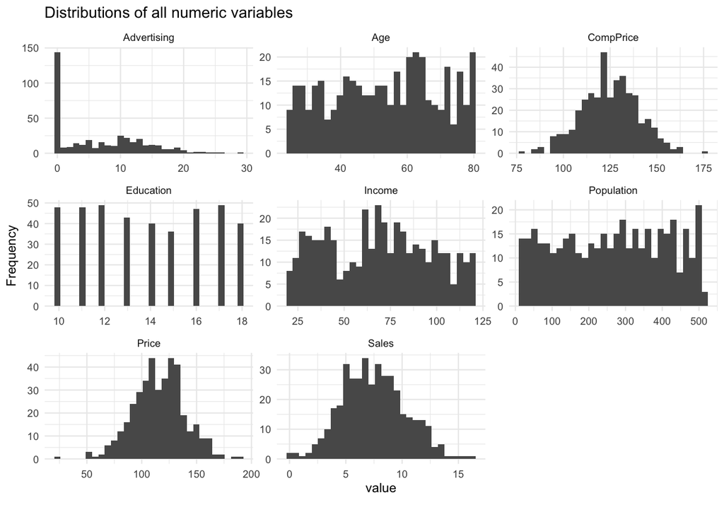

```r
plot_histogram(tbl_carseats, ncol = 3,
               ggtheme = theme_minimal(base_size = 9),
               title = "Distributions of all numeric variables")
```

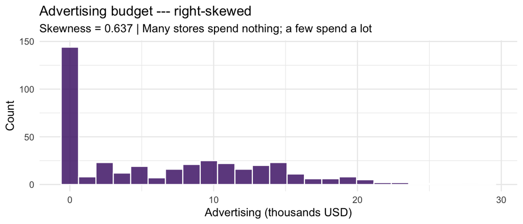

Advertising is right-skewed — a genuine candidate for log transformation.

```r
skew_adv <- round(skewness(tbl_carseats$Advertising), 3)

tbl_carseats |>
  ggplot(aes(x = Advertising)) +
  geom_histogram(bins = 25, fill = "#502479", color = "white", alpha = 0.85) +
  labs(
    title    = "Advertising budget --- right-skewed",
    subtitle = paste0("Skewness = ", skew_adv,
                      " | Many stores spend nothing; a few spend a lot"),
    x = "Advertising (thousands USD)", y = "Count"
  ) +
  theme_minimal(base_size = 11)
```

**Important⚠️ A2: Distributions and Transformations**

1. Describe the distribution of `Sales` in your own words. Is it symmetric, right-skewed, or left-skewed? Does mean ≈ median?
2. Compute skewness for `Sales`, `log(Sales)`, and `Advertising`:

```r
library(moments)
skewness(tbl_carseats$Sales)
skewness(log(tbl_carseats$Sales))
skewness(tbl_carseats$Advertising)
```

3. For which variable is a log transformation more defensible: `Sales` or `Advertising`? Justify based on the skewness values, the histograms, and the theoretical argument (CLT for unit sales vs. power-law for monetary values).
4. Look at the histogram of `Population`. Is this distribution surprising? What might explain it?

## 7 Step 3: Group-Level Descriptives with `group_by()` and `summarise()`

A key strength of EDA in the tidyverse is the ability to compute descriptive statistics *conditional on a grouping variable* using `group_by()` and `summarise()`. This is the most direct bridge from raw data to interpretable patterns.

### 7.1 Sales by Shelf Location

```r
tbl_carseats |>
  group_by(ShelveLoc) |>
  summarise(
    n          = n(),
    mean_sales = round(mean(Sales), 2),
    median_sales = round(median(Sales), 2),
    sd_sales   = round(sd(Sales),   2),
    min_sales  = round(min(Sales),  2),
    max_sales  = round(max(Sales),  2)
  ) |>
  arrange(desc(mean_sales)) |>
  gt() |>
  tab_style(
    style     = cell_fill(color = "#f0fff0"),
    locations = cells_body(rows = ShelveLoc == "Good")
  ) |>
  tab_style(
    style     = cell_fill(color = "#fff0f0"),
    locations = cells_body(rows = ShelveLoc == "Bad")
  ) |>
  tab_options(table.font.size = "13px") |>
  tab_header("Sales by shelf location (ShelveLoc)")
```

Sales by shelf location (ShelveLoc)

| ShelveLoc | n | mean_sales | median_sales | sd_sales | min_sales | max_sales |
| --- | --- | --- | --- | --- | --- | --- |
| Good | 85 | 10.21 | 10.50 | 2.50 | 3.58 | 16.27 |
| Medium | 219 | 7.31 | 7.38 | 2.27 | 0.00 | 13.36 |
| Bad | 96 | 5.52 | 5.21 | 2.36 | 0.37 | 11.67 |

### 7.2 Sales by Urban/US Segment

```r
tbl_carseats |>
  group_by(Urban, US) |>
  summarise(
    n          = n(),
    mean_sales = round(mean(Sales), 2),
    sd_sales   = round(sd(Sales),   2),
    .groups = "drop"
  ) |>
  gt() |>
  tab_options(table.font.size = "13px") |>
  tab_header("Sales by Urban status and US region")
```

Sales by Urban status and US region

| Urban | US | n | mean_sales | sd_sales |
| --- | --- | --- | --- | --- |
| No | No | 46 | 6.46 | 2.72 |
| No | Yes | 72 | 8.27 | 2.64 |
| Yes | No | 96 | 7.00 | 2.54 |
| Yes | Yes | 186 | 7.71 | 2.96 |

### 7.3 Price Distribution by Shelf Location

```r
tbl_carseats |>
  group_by(ShelveLoc) |>
  summarise(
    mean_price = round(mean(Price), 2),
    sd_price   = round(sd(Price),   2),
    n          = n()
  ) |>
  gt() |>
  tab_options(table.font.size = "13px") |>
  tab_header("Price by ShelveLoc",
             subtitle = "Do stores with better shelf space charge higher prices?")
```

Price by ShelveLoc

Do stores with better shelf space charge higher prices?

| ShelveLoc | mean_price | sd_price | n |
| --- | --- | --- | --- |
| Bad | 114.27 | 23.78 | 96 |
| Good | 117.88 | 25.13 | 85 |
| Medium | 115.65 | 23.10 | 219 |

**Important⚠️ A3: Group Comparisons**

1. What is the difference in average sales between “Good” and “Bad” shelf locations? Is this difference large relative to the overall standard deviation of `Sales`?
2. Do stores with better shelf locations also charge higher prices on average? What would this imply for a simple regression of `Sales` on `Price` alone? (This question foreshadows **Omitted Variable Bias** — discussed in Lab 3.)
3. Extend the group-by analysis: compute mean `Sales` and `Advertising` for the four combinations of Urban × US:

```r
tbl_carseats |>
  group_by(Urban, US) |>
  summarise(
    mean_sales = mean(Sales),
    mean_adv   = mean(Advertising),
    n          = n(),
    .groups = "drop"
  )
```

What pattern do you see? Are there systematic differences in advertising spend?

## 8 Step 4: Bivariate Relationships

### 8.1 Price and Sales — A First Look

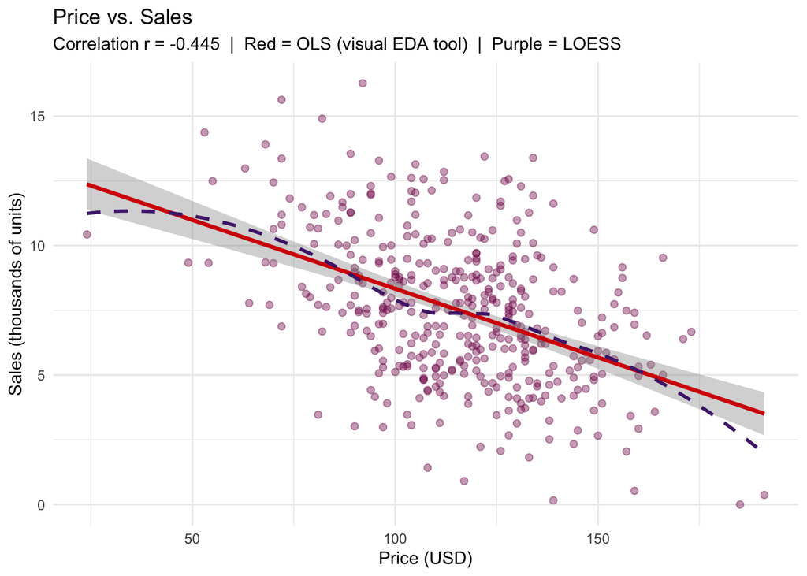

```r
tbl_carseats |>
  ggplot(aes(x = Price, y = Sales)) +
  geom_point(alpha = 0.4, color = "#7d0a52", size = 1.8) +
  geom_smooth(method = "lm",    color = "#D50006",
              se = TRUE,  linewidth = 1.2) +
  geom_smooth(method = "loess", color = "#502479",
              se = FALSE, linewidth = 1, linetype = "dashed") +
  labs(
    title    = "Price vs. Sales",
    subtitle = paste0("Correlation r = ",
                      round(cor(tbl_carseats$Price, tbl_carseats$Sales), 3),
                      "  |  Red = OLS (visual EDA tool)  |  Purple = LOESS"),
    x = "Price (USD)", y = "Sales (thousands of units)"
  ) +
  theme_minimal(base_size = 11)
```

**Note📚 Background: The OLS Line as an EDA Tool**

The regression line in this scatter plot is drawn here purely as an EDA device — a visual summary of the average trend. We are *not* fitting a model for deployment. The shift to formal modelling (Lab 3) happens only after the EDA is complete.

The two lines serve different purposes: the OLS line shows the best-fit linear trend; the LOESS line is a local smoother that reveals non-linearities if present. Their agreement (or disagreement) is informative.

### 8.2 Scatterplot Matrix: All Variables at Once

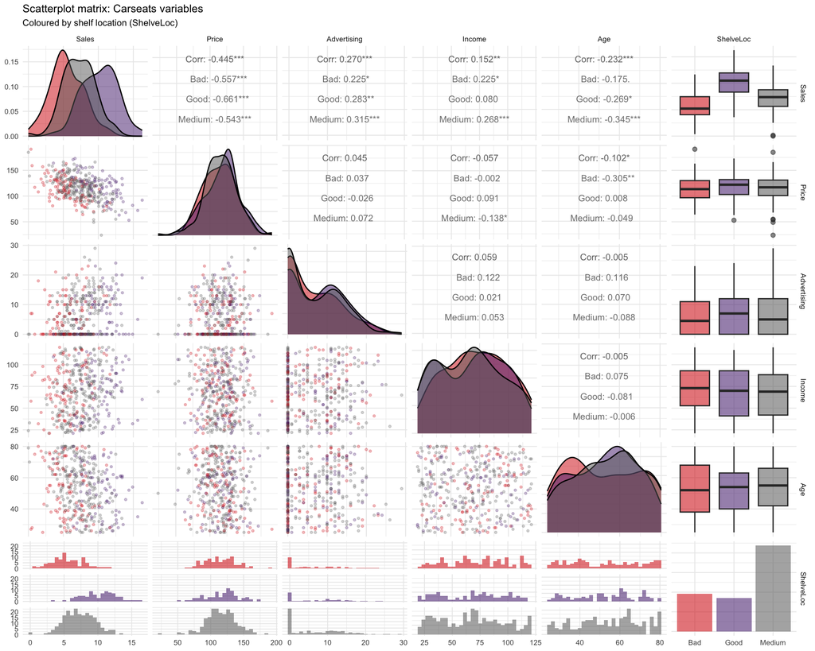

```r
tbl_carseats |>
  select(Sales, Price, Advertising, Income, Age, ShelveLoc) |>
  ggpairs(
    aes(color = ShelveLoc, alpha = 0.4),
    upper = list(continuous = wrap("cor", size = 2.8)),
    lower = list(continuous = wrap("points", alpha = 0.25, size = 0.7)),
    diag  = list(continuous = wrap("densityDiag", alpha = 0.5))
  ) +
  scale_color_manual(values = c(
    "Bad"    = "#D50006",
    "Medium" = "#686868",
    "Good"   = "#502479"
  )) +
  scale_fill_manual(values = c(
    "Bad"    = "#D50006",
    "Medium" = "#686868",
    "Good"   = "#502479"
  )) +
  theme_minimal(base_size = 8) +
  labs(title    = "Scatterplot matrix: Carseats variables",
       subtitle = "Coloured by shelf location (ShelveLoc)")
```

### 8.3 Correlation Matrix

```r
cor_mat <- tbl_carseats |>
  select(Sales, Price, Advertising, Income, Age, Population) |>
  cor() |>
  round(3)

cor_mat |>
  as_tibble(rownames = "variable") |>
  gt() |>
  fmt_number(columns = where(is.numeric), decimals = 3) |>
  data_color(
    columns   = where(is.numeric),
    rows      = everything(),
    palette   = c("#D50006", "white", "#502479"),
    domain    = c(-1, 1)
  ) |>
  tab_options(table.font.size = "12px") |>
  tab_header("Correlation matrix (numeric variables)")
```

Correlation matrix (numeric variables)

| variable | Sales | Price | Advertising | Income | Age | Population |
| --- | --- | --- | --- | --- | --- | --- |
| Sales | 1.000 | −0.445 | 0.270 | 0.152 | −0.232 | 0.050 |
| Price | −0.445 | 1.000 | 0.045 | −0.057 | −0.102 | −0.012 |
| Advertising | 0.270 | 0.045 | 1.000 | 0.059 | −0.005 | 0.266 |
| Income | 0.152 | −0.057 | 0.059 | 1.000 | −0.005 | −0.008 |
| Age | −0.232 | −0.102 | −0.005 | −0.005 | 1.000 | −0.043 |
| Population | 0.050 | −0.012 | 0.266 | −0.008 | −0.043 | 1.000 |

```r
# Ranked correlations with Sales
cor_mat |>
  as_tibble(rownames = "variable") |>
  select(variable, Sales) |>
  filter(variable != "Sales") |>
  arrange(desc(abs(Sales))) |>
  gt() |>
  fmt_number(columns = Sales, decimals = 3) |>
  tab_options(table.font.size = "13px") |>
  tab_header("Correlation with Sales --- ranked by absolute value")
```

Correlation with Sales --- ranked by absolute value

| variable | Sales |
| --- | --- |
| Price | −0.445 |
| Advertising | 0.270 |
| Age | −0.232 |
| Income | 0.152 |
| Population | 0.050 |

**Important⚠️ A4: Bivariate Analysis**

1. Which numeric variable has the **strongest** linear correlation with `Sales`? Which has the weakest?
2. Are there pairs of *predictors* that are strongly correlated with each other (potential multicollinearity)? Why would this matter in a regression model?
3. Inspect the `ggpairs` matrix carefully. The `ShelveLoc` colouring reveals subgroup differences invisible in aggregated correlations:
   - Does the slope of the Price–Sales relationship look different across ShelveLoc groups?
   - What does this imply for modelling?

## 9 Step 5: Boxplots and Conditional Distributions

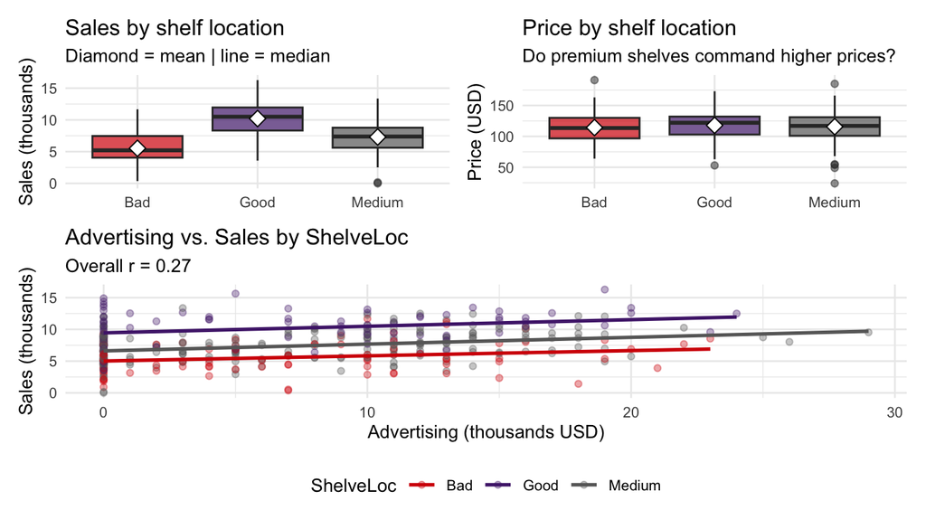

```r
p1 <- tbl_carseats |>
  ggplot(aes(x = ShelveLoc, y = Sales, fill = ShelveLoc)) +
  geom_boxplot(alpha = 0.7, outlier.alpha = 0.5) +
  stat_summary(fun = mean, geom = "point",
               shape = 23, size = 3, fill = "white") +
  scale_fill_manual(values = c("Bad"    = "#D50006",
                               "Medium" = "#686868",
                               "Good"   = "#502479")) +
  labs(title = "Sales by shelf location",
       subtitle = "Diamond = mean | line = median",
       x = NULL, y = "Sales (thousands)") +
  theme_minimal(base_size = 10) +
  theme(legend.position = "none")

p2 <- tbl_carseats |>
  ggplot(aes(x = ShelveLoc, y = Price, fill = ShelveLoc)) +
  geom_boxplot(alpha = 0.7, outlier.alpha = 0.5) +
  stat_summary(fun = mean, geom = "point",
               shape = 23, size = 3, fill = "white") +
  scale_fill_manual(values = c("Bad"    = "#D50006",
                               "Medium" = "#686868",
                               "Good"   = "#502479")) +
  labs(title = "Price by shelf location",
       subtitle = "Do premium shelves command higher prices?",
       x = NULL, y = "Price (USD)") +
  theme_minimal(base_size = 10) +
  theme(legend.position = "none")

p3 <- tbl_carseats |>
  ggplot(aes(x = Advertising, y = Sales,
             color = ShelveLoc)) +
  geom_point(alpha = 0.35, size = 1.4) +
  geom_smooth(method = "lm", se = FALSE, linewidth = 0.9) +
  scale_color_manual(values = c("Bad"    = "#D50006",
                                "Medium" = "#686868",
                                "Good"   = "#502479")) +
  labs(title = "Advertising vs. Sales by ShelveLoc",
       subtitle = paste0("Overall r = ",
                         round(cor(tbl_carseats$Advertising,
                                   tbl_carseats$Sales), 3)),
       x = "Advertising (thousands USD)", y = "Sales (thousands)",
       color = "ShelveLoc") +
  theme_minimal(base_size = 10) +
  theme(legend.position = "bottom")

(p1 + p2) / p3
```

## 10 Step 6: Formulating Hypotheses

The EDA has surfaced several patterns. The next step is to translate observations into testable hypotheses for the modelling phase (Labs 3 and 4).

**Important⚠️ A5: Hypotheses for Modelling**

Based on your EDA, formulate **three hypotheses** relevant to the goal “Identify underperforming stores”.

**Structure:** > *“I expect [variable X] to have a [positive/negative] association with Sales because > [substantive reasoning]. This is visible in [specific EDA finding: table/plot].”*

Additionally:

## 11 Bonus Tasks

**Tip B1: Automated EDA Report**

`DataExplorer` can generate a full HTML EDA report in one line:

```r
# Generates a self-contained HTML report
create_report(tbl_carseats,
              output_file  = "EDA_Carseats_report.html",
              output_dir   = ".",
              report_title = "Carseats EDA Report")
```

Open the report. Which visualisations are most informative? Which would you include in a presentation to management?

**Tip B2: Missing Data Visualisation**

The Carseats data have no missing values — but real datasets rarely do. Explore a dataset with missings using `visdat` and `naniar`:

```r
library(visdat)
library(naniar)

# Visual overview of data types and missings
vis_dat(airquality)

# Summary of missing values
miss_var_summary(airquality)

# Missingness as a pattern
gg_miss_upset(airquality)
```

What patterns do you see? Are certain variables always missing together?

**Tip B3: Segmented EDA**

Conduct the EDA separately for urban and non-urban stores. Do the price and advertising effects differ?

```r
tbl_carseats |>
  ggplot(aes(x = Price, y = Sales, color = Urban)) +
  geom_point(alpha = 0.4, size = 1.5) +
  geom_smooth(method = "lm", se = FALSE, linewidth = 1.2) +
  scale_color_manual(values = c("Yes" = "#502479", "No" = "#D50006")) +
  facet_wrap(~US) +
  labs(title = "Price vs. Sales by location (Urban) and region (US)",
       x = "Price (USD)", y = "Sales (thousands)") +
  theme_minimal()
```

Any indications of interaction effects between Urban status and US region?

## 12 Summary

[output not shown]

**ImportantKey Messages of This Lab**

1. **EDA is CRISP-DM Phase 2.** It follows Business Understanding and precedes all modelling. Its purpose is data comprehension, not prediction.
2. **Never trust a statistic you haven’t plotted.** The Datasaurus Dozen illustrates this dramatically: identical summary statistics, completely different realities.
3. **EDA and Data Mining are both inductive.** They differ in scale, purpose, and success criteria — not in their logical structure. The OLS line in a scatter plot is EDA when it aids understanding; it becomes a DM artefact when evaluated on new data.
4. **The induction trap.** Hypotheses generated from data cannot be tested on those same data. Plan the data split before exploration.
5. **EDA before transformation.** `Sales` is symmetric (CLT applies to store-level unit sales); the log transformation makes it *worse*. `Advertising` is right-skewed and *is* a candidate for transformation. Always check empirically.
6. **`group_by()` + `summarise()` is the most powerful EDA tool in the tidyverse.** Conditional means reveal patterns that global statistics hide.

**NoteTransition to Lab 3**

In Lab 3 we fit the **baseline model** `Sales ~ Price`. The EDA findings predict exactly what we will see: a low $R^2$ (Price alone is not enough) and a systematic ShelveLoc pattern in the residual plot — the signature of **Omitted Variable Bias**.

We will also examine the regression output table critically: since we treat the 400 stores as a population, what do “estimate”, “std_error”, and “p_value” actually mean?